# Ethics, decisions and patient-centred care

Adam La Caze School of Pharmacy The University of Queensland

# Introduction

## Key concepts

1. Healthcare decisions are ethical decisions
2. Patient-centred care is good care. The justification for patient-centred care is ethical.
3. We employ two psychological systems for making decisions. The quick, System 1, and the comprehensive, System 2.
4. You should take a structured approach to making ethical decisions (much like you take a structured approach to clinical decisions)

## Ethics and decisions

Most, if not all, professional decisions in pharmacy have an ethical component.

One way to see this is to reflect on what people *value*.

## People value health

People of very different ages, backgrounds and capacity *value* good health.

This is despite the fact that people often have very different values and very different levels of health.

People value good health—however they perceive “good health”.

## Personal values influence health choices

The *choices* people make with regard to their health is influenced by a wide range of personal values.

People differ greatly in their willingness to accept certain types of treatment, kinds of adverse effects, and levels of risk (among many other things)

Personal values inform health choices, and these vary greatly

## Ethics, decisions and patient-centred care

Put these two together—people value health, and personal values inform health choices—and you get two important consequences.

You are here to help people about something that is very important to them. Part of being a health professional is accepting responsibility for a person’s health in terms of the care you provide.

You need to provide that care in way that is consistent with that person’s values. That is, you need to provide “patient-centred care”

## Healthcare decisions are ethical decisions

Appreciating the role you are playing as a healthcare professional is important.

Many of the things you do as a pharmacist become routine—checking for allergies, consulting with a consumer regarding an antibiotic, dispensing emergency contraception, identifying a potential drug interaction, etc.

When you perform these tasks you make many decisions—given the context you are in, all of these decisions have an ethical component.

## Patient-centred care

Providing patient-centred care is:

Providing care that is respectful of and responsive to individual patient preferences, needs, and values, and ensuring that patient values guide all clinical decisions (Institute of Medicine 2001)

Patient-centred care is good care. It serves as a reminder of what the point of healthcare is. It is important because time pressures, financial pressures and the complexity of health care can make good decisions difficult to make.

## When is care not patient-centred

Pharmacists fail to achieve the goal of patient-centred care when they:

- Focus on a list of medicines rather than the patient taking those medicines
- Counsel patients rather than consult with them
- Fail to explore the patient’s reasons and expectations in relation to their medicines

# Decisions and heuristics

## Why isn’t the ethical dimension of our decisions more obvious?

Sure there are some *big* ethical questions—suicide, abortion, drug addiction,…—and these can take time to think through.

But for most of our day-to-day decisions we don’t seem to spend much time thinking about ethics.

Ethical decisions are like any other decision, they are informed by our values and our experiences.

We develop quite sophisticated sets of heuristics (rules of thumb) to handle the most common scenarios quickly and easily

Mostly these heuristics work very well, but sometimes they lead us astray—it is important to recognise the heuristics you use and to reflect on the values that underpin them

## Example

Let’s say that these two people present to your community pharmacy with similar symptoms and request a pseudoephedrine-containing cold and flu product.

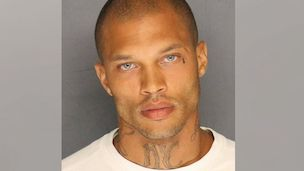

[figure not shown]

Chances are you are likely to treat their request differently, and to the extent that you do so it will be informed by a heuristic (which in turn is informed by explicit and implicit value judgements)

## Decisions and heuristics

Daniel Kahneman is a psychologist who has done a lot of work on how people make decisions (Kahneman 2011).

His work identifies two systems

**System 1** operates automatically and quickly, with little or no effort and no sense of voluntary control

**System 2** allocates attention to the effortful mental activities that demand it, including complex computations.

Recognising these systems is helpful for thinking about ethical decisions in pharmacy

## Day-to-day decisions

There are some decisions that we make a lot.

- When do you sell pseudoephedrine?
- Which patients do you prioritise on the ward?
- How much discussion do you have with a consumer purchasing OTC salbutamol?
- Do you sell sharps kits?
- Do you provide emergency supply when the patient’s doctor can’t be contacted

Most pharmacists will rely on *System 1* for these types of decisions.

## Reflecting on day-to-day decisions

When starting out, either as an intern or coming to a new area of practice, you often need to think through the day-to-day decisions of an area more deliberately—here you use *System 2*.

There is good and bad about this.

You take longer to make what is seen as a routine decision

But you think that decision through more carefully

## Reflecting on day-to-day decisions

Sometime after it has shifted to a routine decision, it is important to reflect on whether you are making the *right* decision

- Are you achieving what you set out to achieve?
- Are there any bad consequences to the approach you are taking?—maybe your approach works for 90% of cases, but turns out spectacularly wrong in the other 10%
- Can you justify your decision?
- Is your decision in line with professional standards?

## Difficult decisions

When matters arise that are not routine you need to engage *System 2*.

- A customer on high doses of morphine inquires about assisted-euthanasia.
- A regular customer appears to be escalating their benzodiazepine use beyond what is prescribed.

These decisions often need some thinking and a careful consideration of the context.

## Take home point

You need a framework for thinking through ethical decisions

This framework is important to both day-to-day decisions and more difficult decisions.

Most day-to-day decisions were once difficult decisions.

And once something has become a routine day-to-day decision it can be even more important to review it on occasion.

You make routine decisions routinely—if you are getting it wrong the harms may accumulate

# A model for ethical decision making

## Why do I need a model for ethical decision-making?

The downside of both the *principles of bioethics* and the codes of conduct/ethics are that they are not very explicit in regards to how to go about making ethical decisions.

The model we will focus on (and use in the tutorial) outlines the process that is expected of you in your intern year.

## A model for ethical decision-making

1. Identify the problem and possible consequences of the problem
   - What facts are available?
   - What facts are still required?
   - What is the ethical problem? (Is there a conflict between two or more guiding principles?)
   - What harms are you concerned about? Who is affected?
2. Identify relevant law and professional standards that apply to the case
   - What are your legal responsibilities?
   - What are your professional responsibilities?
   - How can you fulfil your legal and professional responsibilities in a way that brings about the best outcome in the situation?
3. Identify the available options for resolving the problem and the reasons for or against each one
4. Formulate a plan of action to resolve the problem
   - What do you need to put in place to improve the chances of a successful outcome?
   - How will you mitigate any risks you have identified?

## Putting the model to work

Most of the steps in this framework are self-explanatory. You will get an opportunity to put the model to work in the tutorial.

Some things to keep in mind:

- Thinking through who might be harmed (and how they could be harmed) is often a good place to start with an ethical challenge.
- It is important to think an issue through from multiple perspectives: the patient, the carer, the prescriber, the nurse and your perspective
- If we have a clinical question we don’t hesitate to search the available literature for an answer—searching the literature for an ethical problem can be just as helpful
- Sometimes in the face of a difficult decision it can be tempting to do nothing. Remember: doing nothing is just as much a decision any other action—can you justify your inaction?

## Next step

[Privacy Law and Ethics](https://alacaze.github.io/pres/02-ethicsmodule.html)

## References

Institute of Medicine. 2001. *Crossing the Quality Chasm: A New Health System for the 21st Century*. The National Academies Press.

Kahneman, Daniel. 2011. *Thinking, Fast and Slow*. Macmillan.